# racoon - CLIP processing report

Melina Klostermann

09 October, 2023

# 1 Overview over raccon steps

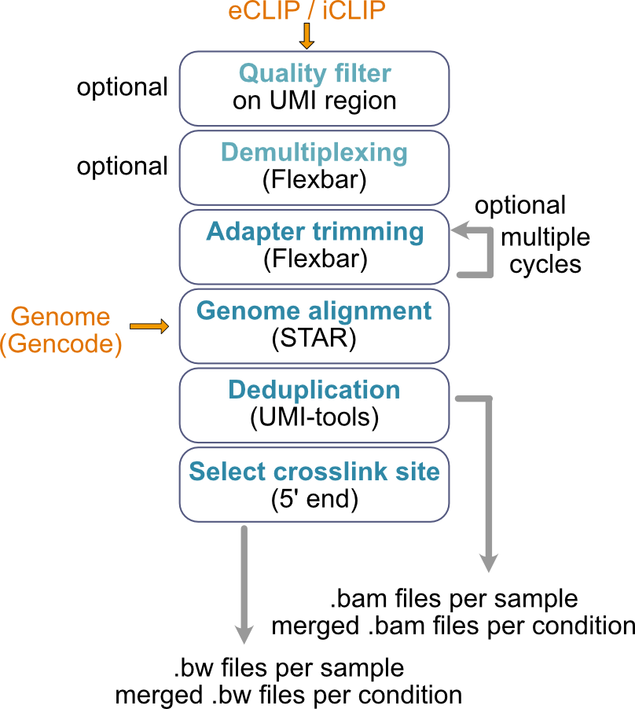

# 2 Configurations

Here is a summary off the settings you chose for this analysis.

|  | config |
| --- | --- |
| adapter_cycles | 2 |
| adapter_file | /media/storage/home/mklostermann/racoon_clip/racoon_clip/workflow/params.dir/adapter.fa |
| adapter_trimming | TRUE |
| barcodeLength | 0 |
| barcodes_fasta |  |
| deduplicate | True |
| demuliplex | FALSE |
| demultiplex | False |
| encode | False |
| encode_umi_length | 10 |
| experiment_group_file | /media/storage/home/mklostermann/projects/07_processed_published_data/Encode/U2AF2_HepG2/01_files_for_pipe/groups_single_end.txt |
| experiment_groups | U2AF2_HepG2_R2 |
| experiment_type | eCLIP_ENCODE |
| experimental_barcode_len | 0 |
| flexbar_minReadLength | 15 |
| genome_fasta | /media/storage/home/mklostermann/annotations/GRCh38.p12.genome.fa |
| gtf | /media/storage/home/mklostermann/annotations/gencode.v30.annotation.gtf |
| gz | TRUE |
| infiles | /media/storage/home/mklostermann/projects/07_processed_published_data/Encode/U2AF2_HepG2/00_raw/U2AF2_HepG2_s1_R2.fastq.gz /media/storage/home/mklostermann/projects/07_processed_published_data/Encode/… |
| log | racoon_clip.log |
| minBaseQuality | 10 |
| min_read_length | 15 |
| moreSTARParameters |  |
| outFilterMismatchNmax | 999 |
| outFilterMismatchNoverReadLmax | 0.04 |
| outFilterMultimapNmax | 1 |
| outReadsUnmapped | Fastx |
| outSJfilterReads | Unique |
| quality_filter_barcodes | FALSE |
| read_length | 45 |
| samples | U2AF2_HepG2_s1_R2 U2AF2_HepG2_s2_R2 |
| seq_format | -Q33 |
| snakebase | /media/storage/home/mklostermann/racoon_clip/racoon_clip/workflow |
| umi1_len | 0 |
| umi2_len | 0 |
| wdir | /media/storage/home/mklostermann/projects/07_processed_published_data/Encode/U2AF2_HepG2/03_racoon_single_strand |
| exp_barcode_len | 0 |

## 2.1 Input files

|  | Input |
| --- | --- |
| infiles | /media/storage/home/mklostermann/projects/07_processed_published_data/Encode/U2AF2_HepG2/00_raw/U2AF2_HepG2_s1_R2.fastq.gz /media/storage/home/mklostermann/projects/07_processed_published_data/Encode/… |
| barcodes_fasta |  |
| gtf | /media/storage/home/mklostermann/annotations/gencode.v30.annotation.gtf |
| genome_fasta | /media/storage/home/mklostermann/annotations/GRCh38.p12.genome.fa |

## 2.2 Options

|  | Option |
| --- | --- |
| demuliplex | False |
| adapter_trimming | TRUE |
| quality_filter_barcodes | FALSE |
| encode | False |
| deduplicate | True |

## 2.3 Barcode settings

|  | Setting |
| --- | --- |
| barcodeLength | 0 |
| minBaseQuality | 10 |
| umi1_len | 0 |
| umi2_len | 0 |
| exp_barcode_len | 0 |
| samples | U2AF2_HepG2_s1_R2 U2AF2_HepG2_s2_R2 |
| encode | False |
| encode_umi_length | 10 |

## 2.4 Read filter

|  | Setting |
| --- | --- |
| min_read_length | 15 |

## 2.5 Alignment setting (STAR)

|  | Setting |
| --- | --- |
| read_length | 45 |
| outFilterMismatchNoverReadLmax | 0.04 |
| outFilterMismatchNmax | 999 |
| outFilterMultimapNmax | 1 |
| outReadsUnmapped | Fastx |
| outSJfilterReads | Unique |
| moreSTARParameters |  |

## 2.6 Experiemnt groups

| Group | Sample |
| --- | --- |
| U2AF2_HepG2_R2 | U2AF2_HepG2_s1_R2 |
| U2AF2_HepG2_R2 | U2AF2_HepG2_s2_R2 |

# 3 Quality control of raw files

Initial quality control of the raw sequencing file is performed with FastQC. Here you can see the sequencing quality and contend per base.

## 3.1 Quality scores across all bases

### U2AF2_HepG2_s1_R2

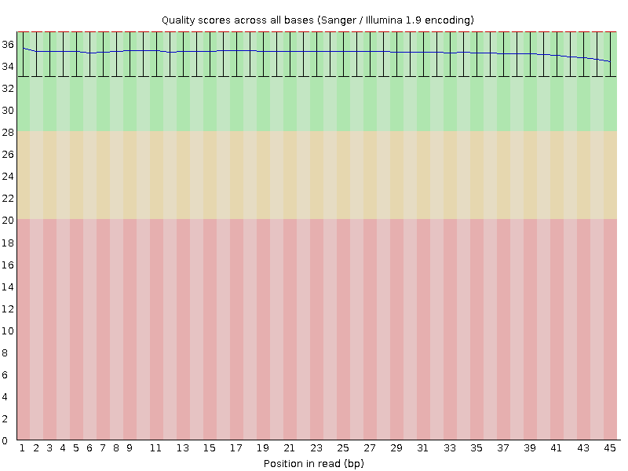

### U2AF2_HepG2_s2_R2

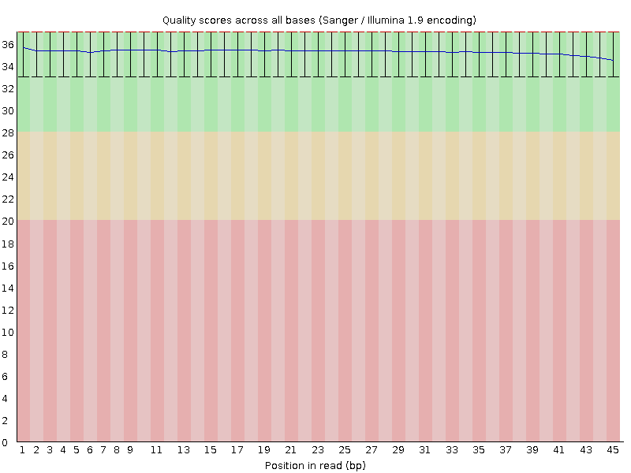

## 3.2 Sequence content across all bases

### U2AF2_HepG2_s1_R2

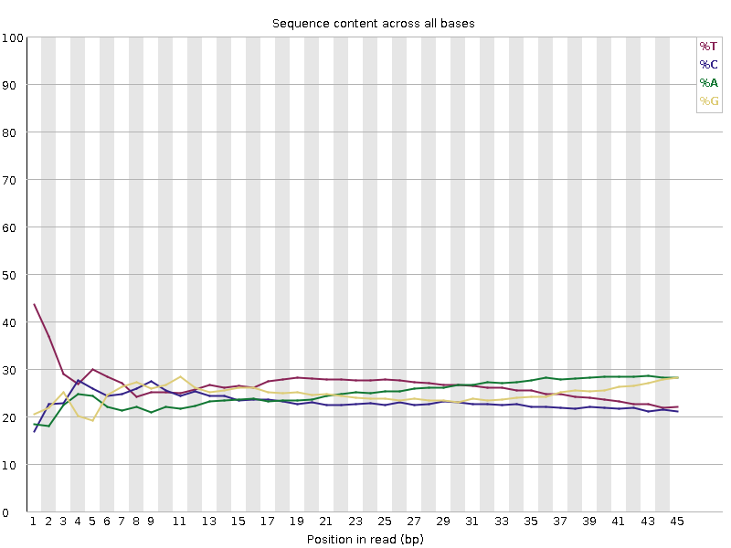

### U2AF2_HepG2_s2_R2

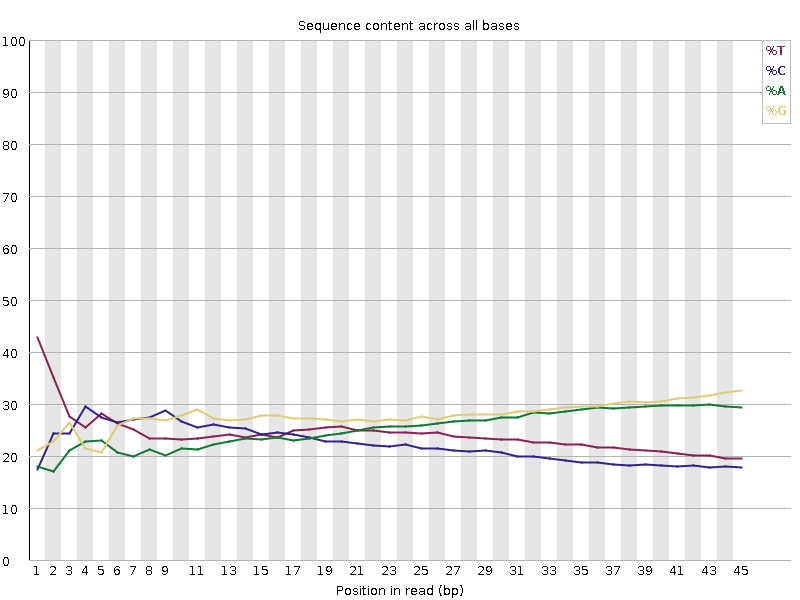

| Sample | Total Sequences | Total Bases | Sequences flagged as poor quality | avg_sequence_length |
| --- | --- | --- | --- | --- |
| trimmed_U2AF2_HepG2_s1_R2 | 10315676 | 391.9 Mbp | 0 | 37.99489 |
| trimmed_U2AF2_HepG2_s2_R2 | 8444544 | 315.8 Mbp | 0 | 37.40046 |

# 4 Adapter trimming

Adapters are trimmed with flexbar, which would be used for demultiplexing on multiplex data. This should garantee the comaparability off multiplexed and demultiplexed data sets. Used adapters are specified with adapter_file (and adapter_file_R2). The default file contains standard Illumina and eCLIP adapters. The adapters are trimmed from the 3’end of the read (–adapter-trim-end RIGHT), with a allowed error of 0.1 (–adapter-error-rate 0.1). The adapter needs to overlap for at least 1nt witht he read (–adapter-min-overlap 1). Adapter trimming can be performed in mutiple cycles as sepcified by the user, here 2 (adapterCycles, see configrations). Reads shorter then 15 are discarded (min_read_length, see configurartions). UMIs are written into the read header with (–umi-tags). If data is from ENCODE, UMIs are already removed from the reads and written in the beginning of the header. As umi-tools dedup which is used for deduplication here expects the UMI to be in the end of the read,encode can be specified to move the UMI from the beginning of the read header to the end (see configurations).

## 4.1 Adapter Content before trimming

Position of adapters found in the reads. If adapters are found early in the reads, this points to overdigestion of the samples.

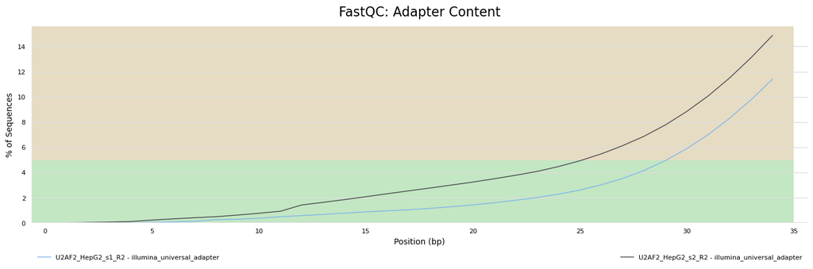

## 4.2 Adapter content after trimming

**Trimming successfull, no adapter content left.**

# 5 Mapping

The genome annotation is indexed with STAR –runMode genomeGenerate. Then the merged file of the chimeric reads is aligned to the genome annotation with STAR –runMode alignReads. For STAR settings see configurations. Obtained bam files are indexed with samtools index.

|  | U2AF2_HepG2_s1_R2 | U2AF2_HepG2_s2_R2 |
| --- | --- | --- |
| Number of input reads | 10315676 | 8444544 |
| Uniquely mapped reads number | 7237664 | 5423221 |
| Uniquely mapped reads % | 70.16% | 64.22% |
| Number of reads mapped to multiple loci | 0 | 0 |
| % of reads mapped to multiple loci | 0.00% | 0.00% |
| Number of reads mapped to too many loci | 2246526 | 2033553 |
| % of reads mapped to too many loci | 21.78% | 24.08% |
| Number of reads unmapped: too many mismatches | 157535 | 142484 |
| % of reads unmapped: too many mismatches | 1.53% | 1.69% |
| Number of reads unmapped: too short | 532325 | 762846 |
| % of reads unmapped: too short | 5.16% | 9.03% |
| Number of reads unmapped: other | 141626 | 82440 |
| % of reads unmapped: other | 1.37% | 0.98% |

[figure not shown]

# 6 Deduplication

Reads are deduplicated with umi_tools dedup –extract-umi-method read_id –method unique.

|  | Reads | Crosslink events (without PCR duplictaes) | Crosslinked nucleotides | Mean crosslink events per crosslinked nulecotide |
| --- | --- | --- | --- | --- |
| U2AF2_HepG2_s1_R2 | 7237664 | 7043799 | 5867093 | 1.20 |
| U2AF2_HepG2_s2_R2 | 5423221 | 5256518 | 4415396 | 1.19 |

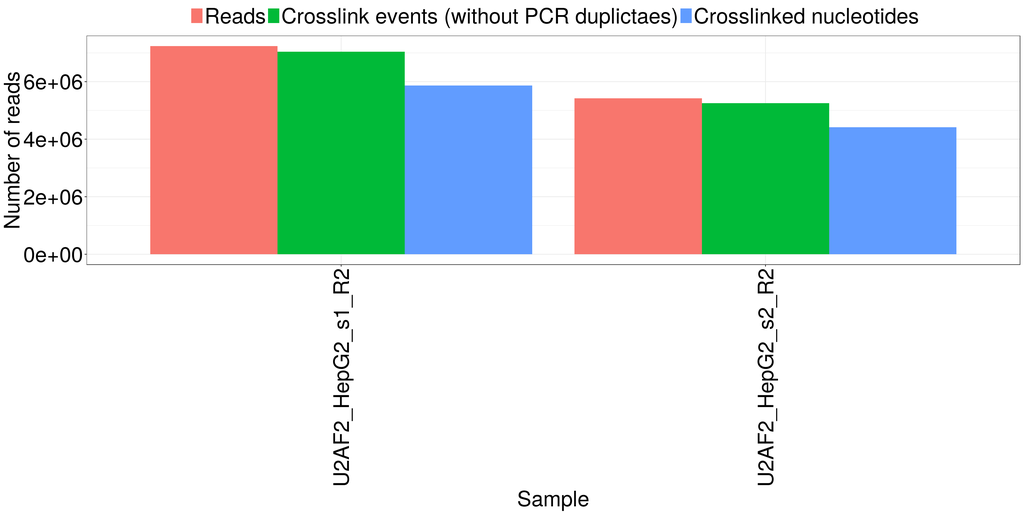

## 6.1 Obtaining crosslinks

The deduplicated bam files are then converted into bed files with bedtools bamtobed. The reads are shifted 1nt upstream (5’ direction) with bedtools shift -m 1 -p -1 because the UV-crosslink should be positioned 1nt before. To allow visualization in a genome browser the 1nt crosslink bed file is then also converted to .bigWig file using bedGraphToBigWig. Furthermore these bigWig files are merged with bigWigMerge by the experiment groups, specified by the user.